# Experiment 1

## (1) Description of Data File

The posted data for this study consists of 1 compiled, deidentified data file (total *N* recruited = 76). No data were excluded.

## (2) Descriptive Statistics (Table 1)

**M<sub>age</sub> (*SD*):** 18.8 (0.9)

**Percentage by gender:**

```
## gender
##   <NA>   male female
##    1.3   43.4   55.3
```

**Percentage by race:**

```
## race
##        White        Asian       Latino Multi-racial        Black         <NA>
##         50.0         35.5          6.6          5.3          1.3          1.3
```

**Percentage by class:**

```
## class
##  Freshman Sophomore    Junior    Senior      <NA>
##      75.0      14.5       5.3       5.3       0.0
```

**Percentage by income:**

```
## income.label
##   (1) $25,000 or less   (2) $25,001-$40,000   (3) $40,001-$70,000   (4) $70,001-$90,000
##                  10.5                   9.2                  15.8                  19.7
##  (5) $90,001-$120,000 (6) $120,001-$150,000 (7) $150,001-$200,000 (8) $200,001-$300,000
##                  10.5                   6.6                   3.9                   2.6
##  (9) $300,001 or more                  <NA>
##                   5.3                  15.8
```

*M*s and *SD*s for income, efficacy (eff), expected graduating GPA (ggpa), and current GPA (cgpa):

*Note:* The *M* and *SD* for current GPA are slightly misreported in the published paper due to typoes. Correcting those values (as done here) does not change any conclusions or central values discussed in the paper.

```
##         n mean   sd
## income 64 4.08 2.18
## eff    76 5.14 1.04
## ggpa   75 3.53 0.33
## cgpa   72 3.43 0.40
```

**$\alpha$<sub>efficacy</sub>:** 0.79

## (3) Random Assignment Checks

**(a) Unequal variance test, *t*-test, and *M*s and *SD*s for: income**

```
##
##  F test to compare two variances
##
## data:  income by cond
## F = 1.3509, num df = 34, denom df = 28, p-value = 0.4182
## alternative hypothesis: true ratio of variances is not equal to 1
## 95 percent confidence interval:
##  0.6488086 2.7425241
## sample estimates:
## ratio of variances
##           1.350934
```

```
##
##  Two Sample t-test
##
## data:  income by cond
## t = -0.42792, df = 62, p-value = 0.6702
## alternative hypothesis: true difference in means is not equal to 0
## 95 percent confidence interval:
##  -1.3354335  0.8644975
## sample estimates:
##   mean in group warm mean in group chilly
##             3.971429             4.206897
```

```
##
##  Descriptive statistics by group
## group: warm
##    vars  n mean   sd median trimmed  mad min max range skew kurtosis   se
## X1    1 35 3.97 2.33      4    3.79 2.97   1   9     8 0.52    -0.69 0.39
## ---------------------------------------------------------------------------
## group: chilly
##    vars  n mean   sd median trimmed  mad min max range skew kurtosis   se
## X1    1 29 4.21 2.01      4    4.08 1.48   1   9     8  0.8     0.32 0.37
```

**(b) Unequal variance test, *t*-test, and *M*s and *SD*s for: current GPA**

```
##
##  F test to compare two variances
##
## data:  cgpa by cond
## F = 0.57857, num df = 37, denom df = 33, p-value = 0.1075
## alternative hypothesis: true ratio of variances is not equal to 1
## 95 percent confidence interval:
##  0.292755 1.128524
## sample estimates:
## ratio of variances
##          0.5785702
```

```
##
##  Two Sample t-test
##
## data:  cgpa by cond
## t = 0.0016867, df = 70, p-value = 0.9987
## alternative hypothesis: true difference in means is not equal to 0
## 95 percent confidence interval:
##  -0.1883770  0.1886959
## sample estimates:
##   mean in group warm mean in group chilly
##             3.425395             3.425235
```

```
##
##  Descriptive statistics by group
## group: warm
##    vars  n mean   sd median trimmed  mad min max range  skew kurtosis   se
## X1    1 38 3.43 0.35    3.5    3.44 0.37 2.5   4   1.5 -0.54     -0.2 0.06
## ---------------------------------------------------------------------------
## group: chilly
##    vars  n mean   sd median trimmed  mad  min max range  skew kurtosis   se
## X1    1 34 3.43 0.45   3.58    3.47 0.32 2.33   4  1.67 -0.95     -0.2 0.08
```

## (4) Main Analyses

### Regressing efficacy on condition, income, and their interaction (Table 2)

#### Omnibus test

**Estimates:**

```
##
## Call:
## lm(formula = eff ~ income_c * cond.num)
##
## Residuals:
##     Min      1Q  Median      3Q     Max
## -2.6684 -0.5103  0.1391  0.5454  1.7316
##
## Coefficients:
##                   Estimate Std. Error t value Pr(>|t|)
## (Intercept)        5.17602    0.12292  42.108   <2e-16 ***
## income_c           0.12650    0.05839   2.166   0.0343 *
## cond.num           0.09201    0.12292   0.749   0.4571
## income_c:cond.num -0.13154    0.05839  -2.253   0.0279 *
## ---
## Signif. codes:  0 '***' 0.001 '**' 0.01 '*' 0.05 '.' 0.1 ' ' 1
##
## Residual standard error: 0.9774 on 60 degrees of freedom
##   (12 observations deleted due to missingness)
## Multiple R-squared:  0.1208, Adjusted R-squared:  0.07684
## F-statistic: 2.748 on 3 and 60 DF,  p-value: 0.05061
```

**CIs:**

```
##                   2.5 % 97.5 %
## (Intercept)        4.93   5.42
## income_c           0.01   0.24
## cond.num          -0.15   0.34
## income_c:cond.num -0.25  -0.01
```

*f*<sup>2</sup> value (effect size) for interaction term: 0.085

#### Simple slopes tests

**Simple slopes of condition among low- and high-SES students:**

```
##        [,1]
## warm      1
## chilly   -1
```

```
##
## ** Estimated points of eff  **
##
##                       Low cond.num (-1 SD) High cond.num (+1 SD)
## Low income_c (-1 SD)                4.5564                5.3158
## High income_c (+1 SD)               5.6283                5.2382
##
##
##
## ** Simple Slopes analysis ( df= 60 ) **
##
##                       simple slope standard error t-value p.value
## Low income_c (-1 SD)         0.378          0.178    2.12   0.038 *
## High income_c (+1 SD)       -0.194          0.175   -1.11   0.272
## ---
## Signif. codes:  0 '***' 0.001 '**' 0.01 '*' 0.05 '.' 0.1 ' ' 1
##
##
##
## ** Bauer & Curran 95% CI **
##
##          lower CI upper CI
## income_c  -1.6475   7.1579
```

**CIs for simple slope among low-SES students:** 0.02, 0.74

**CIs for simple slope among high-SES students:** -0.54, 0.16  
**Simple slope of income in each condition (Footnote 3):**

```
##        [,1]
## warm      1
## chilly   -1
```

```
##
## ** Estimated points of eff  **
##
##                       Low income_c (-1 SD) High income_c (+1 SD)
## Low cond.num (-1 SD)                4.5564                5.6283
## High cond.num (+1 SD)               5.3158                5.2382
##
##
##
## ** Simple Slopes analysis ( df= 60 ) **
##
##                       simple slope standard error t-value p.value
## Low cond.num (-1 SD)        0.2462         0.0880    2.80  0.0069 **
## High cond.num (+1 SD)      -0.0178         0.0755   -0.24  0.8142
## ---
## Signif. codes:  0 '***' 0.001 '**' 0.01 '*' 0.05 '.' 0.1 ' ' 1
##
##
##
## ** Bauer & Curran 95% CI **
##
##          lower CI upper CI
## cond.num   0.1098   6.2944
```

**CIs for simple slope among students in the chilly climate condition:** 0.07, 0.42  
**CIs for simple slope among students in the warm climate condition:** -0.17, 0.13

### Regressing expected graduating GPA on condition, income, and their interaction (Table 2)

#### Omnibus test

**Estimates:**

```
##
## Call:
## lm(formula = ggpa ~ income_c * cond.num)
##
## Residuals:
##     Min      1Q  Median      3Q     Max
## -1.2955 -0.1088  0.1064  0.2293  0.3697
##
## Coefficients:
##                    Estimate Std. Error t value Pr(>|t|)
## (Intercept)        3.519328   0.042725  82.372   <2e-16 ***
## income_c           0.025217   0.020672   1.220   0.2274
## cond.num           0.009482   0.042725   0.222   0.8251
## income_c:cond.num -0.044405   0.020672  -2.148   0.0358 *
## ---
## Signif. codes:  0 '***' 0.001 '**' 0.01 '*' 0.05 '.' 0.1 ' ' 1
##
## Residual standard error: 0.3353 on 59 degrees of freedom
##   (13 observations deleted due to missingness)
## Multiple R-squared:  0.07825,    Adjusted R-squared:  0.03139
## F-statistic:  1.67 on 3 and 59 DF,  p-value: 0.1833
```

**CIs:**

```
##                    2.5 % 97.5 %
## (Intercept)        3.434  3.605
## income_c          -0.016  0.067
## cond.num          -0.076  0.095
## income_c:cond.num -0.086 -0.003
```

*f*<sup>2</sup> value (effect size) for interaction term: 0.078

#### Simple slopes tests

**Simple slopes of condition among low- and high-SES students:**

```
##        [,1]
## warm      1
## chilly   -1
```

```
##
## ** Estimated points of ggpa  **
##
##                       Low cond.num (-1 SD) High cond.num (+1 SD)
## Low income_c (-1 SD)                3.3742                3.5809
## High income_c (+1 SD)               3.6539                3.4764
##
##
##
## ** Simple Slopes analysis ( df= 59 ) **
##
##                       simple slope standard error t-value p.value
## Low income_c (-1 SD)        0.1032         0.0628    1.64    0.11
## High income_c (+1 SD)      -0.0886         0.0607   -1.46    0.15
##
##
##
## ** Bauer & Curran 95% CI **
##
##          lower CI upper CI
## income_c  -3.9456   5.3146
```

**CIs for simple slope among low-SES students:** -0.02, 0.23

**CIs for simple slope among high-SES students:** -0.21, 0.03  
**Simple slopes of income in each condition (Footnote 3):**

```
##        [,1]
## warm      1
## chilly   -1
```

```
##
## ** Estimated points of ggpa  **
##
##                       Low income_c (-1 SD) High income_c (+1 SD)
## Low cond.num (-1 SD)                3.3742                3.6539
## High cond.num (+1 SD)               3.5809                3.4764
##
##
##
## ** Simple Slopes analysis ( df= 59 ) **
##
##                       simple slope standard error t-value p.value
## Low cond.num (-1 SD)        0.0648         0.0314    2.06   0.044 *
## High cond.num (+1 SD)      -0.0242         0.0261   -0.93   0.358
## ---
## Signif. codes:  0 '***' 0.001 '**' 0.01 '*' 0.05 '.' 0.1 ' ' 1
##
##
##
## ** Bauer & Curran 95% CI **
##
##          lower CI upper CI
## cond.num  -0.6654   4.5785
```

**CIs for simple slope among students in the chilly climate condition:** 0.002, 0.128

**CIs for simple slope among students in the warm climate condition:** -0.076, 0.028

### Analyses with subjective SES (Footnote 2)

**For efficacy:**

```
##
## Call:
## lm(formula = eff ~ ladder_c * cond.num)
##
## Residuals:
##     Min      1Q  Median      3Q     Max
## -2.7168 -0.5222  0.2508  0.6315  1.9157
##
## Coefficients:
##                   Estimate Std. Error t value Pr(>|t|)
## (Intercept)        5.17607    0.13807  37.489   <2e-16 ***
## ladder_c           0.16418    0.06889   2.383   0.0206 *
## cond.num          -0.14831    0.13807  -1.074   0.2874
## ladder_c:cond.num -0.01651    0.06889  -0.240   0.8115
## ---
## Signif. codes:  0 '***' 0.001 '**' 0.01 '*' 0.05 '.' 0.1 ' ' 1
##
## Residual standard error: 1.033 on 55 degrees of freedom
##   (17 observations deleted due to missingness)
## Multiple R-squared:  0.09911,    Adjusted R-squared:  0.04997
## F-statistic: 2.017 on 3 and 55 DF,  p-value: 0.1222
```

**For expected graduating GPA:**

```
##
## Call:
## lm(formula = ggpa ~ ladder_c * cond.num)
##
## Residuals:
##      Min       1Q   Median       3Q      Max
## -1.46434 -0.07665  0.06582  0.18461  0.34838
##
## Coefficients:
##                   Estimate Std. Error t value Pr(>|t|)
## (Intercept)        3.54343    0.04097  86.485  < 2e-16 ***
## ladder_c           0.06004    0.02057   2.919  0.00511 **
## cond.num          -0.01826    0.04097  -0.446  0.65753
## ladder_c:cond.num  0.01689    0.02057   0.821  0.41526
## ---
## Signif. codes:  0 '***' 0.001 '**' 0.01 '*' 0.05 '.' 0.1 ' ' 1
##
## Residual standard error: 0.305 on 54 degrees of freedom
##   (18 observations deleted due to missingness)
## Multiple R-squared:  0.1673, Adjusted R-squared:  0.1211
## F-statistic: 3.617 on 3 and 54 DF,  p-value: 0.01875
```

## (5) Figures

### Regressing efficacy on condition, income, and their interaction (Figure 1a)

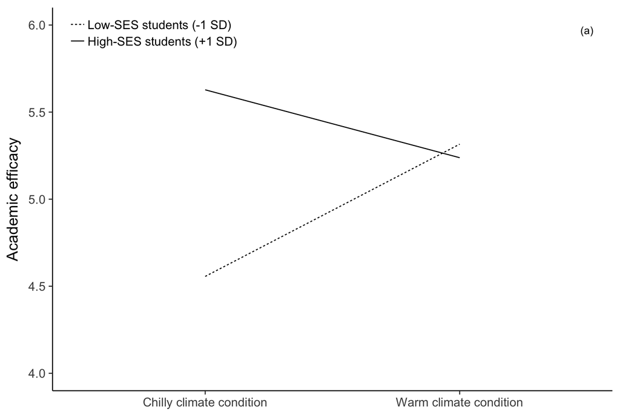

### Regressing expected graduating GPA on condition, income, and their interaction (Figure 1b)

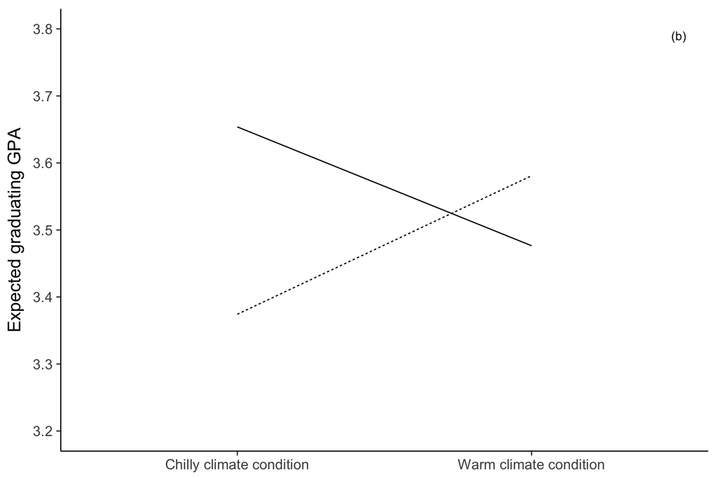